# Appendix1: Study Area and Data Collection

# 1 Study Area and Data Collection

## 1.1 Study Area

The study area for this chapter covers most parts of the Jung and Jongno districts (16.6km<sup>2</sup>) which is the CBD of Seoul. This CBD zone is also referred to as the “Sadaemoon” area, known as the four gates named by the previous monarchy. There are eight sub-districts[^1] in the Jongno district and seven sub-districts[^2] in Jung. This area plays a central role in business, tourism, shopping, and transit to sub-civic centres.

To improve urban air quality, Seoul planned a Green Transport Scheme which set a clean air zone within the four gates of central Seoul. Unlike London’s ULEZ (Ultra Low Emission Zone), the government has fined vehicles that do not meet the emission standards since December 2019. Despite the attempt to provide better air quality for citizens and commuters, there are still concerns about whether the reduced traffic has benefited air quality since the commencement of peak hours, or has caused another problem for those drivers whose vehicles do not meet the standard who coercively have to change their mode of transport.

Seoul CBD was chosen because first, approximately 300,000 people and 1.3 million vehicles commute to the area every day, second, direct and indirect effects from the exhaust and non-exhaust emissions release notorious levels of particulates which can affect residents’ and commuters’ health, and lastly, hardly any scientific studies have discovered the association between vehicle ban and air quality after the ‘Green Transport Scheme’ was initiated. More TRAP studies, such as London Low Emission Zone (LEZ) are needed (Kelly et al. 2011; Sean D. Beevers et al. 2013; Sean David Beevers 2016; Halonen et al. 2016).

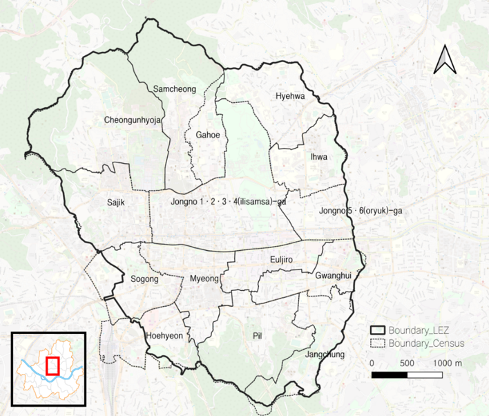

Study area - Seoul Central Business District. This area includes Jongno and Jung districts

## 1.2 Air Pollution

Hourly measured PM<sub>10</sub> was imported from two urban background stations, Jongno and Jung, and two roadside stations, Jongno and Seoul Station, provided by the National Institute of Environmental Research. Assuming subway commuters travel outside the CBD area, PM<sub>10</sub> was also collected and averaged from 23 background and 12 roadside stations within the city boundary. The collection period was set between January 1st-March 31st, 2018, considering high concentrations and variations of PM<sub>10</sub> during the winter period. The study chose the three months for which the data were available in the Seoul Institute repository.

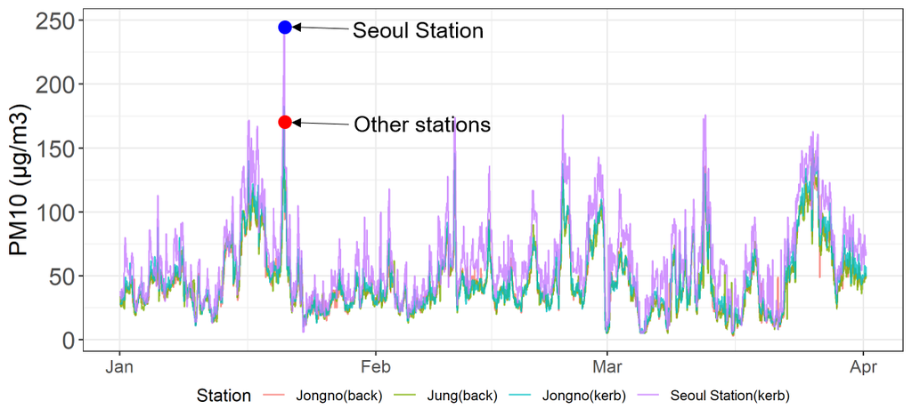

# References

Beevers, Sean David. 2016. “Traffic management strategies for emissions reduction : recent experience in London,” 27–39.

Beevers, Sean D, Nutthida Kitwiroon, Martin L Williams, Frank J Kelly, H Ross Anderson, and David C Carslaw. 2013. “Air pollution dispersion models for human exposure predictions in London.” *Journal of Exposure Science & Environmental Epidemiology* 23 (6): 647–53. https://doi.org/10.1038/jes.2013.6.

Halonen, Jaana I, Marta Blangiardo, Mireille B Toledano, Daniela Fecht, John Gulliver, H Ross Anderson, Sean D Beevers, David Dajnak, Frank J Kelly, and Cathryn Tonne. 2016. “Long-term exposure to traffic pollution and hospital admissions in London.” *Environmental Pollution* 208: 48–57. https://doi.org/10.1016/j.envpol.2015.09.051.

Kelly, Frank, Ben Armstrong, Richard Atkinson, H Ross Anderson, Ben Barratt, Sean Beevers, Derek Cook, et al. 2011. “The London low emission zone baseline study.” *Research Report (Health Effects Institute)*, no. 163: 3–79. http://europepmc.org/abstract/MED/22315924.

[^1]: Sajik, Cheongwoonhyoja, Samcheong, Gahoe, Jongno 1-4ga, Jongno 5-6ga, Ewha, and Hyewha
[^2]: Sogong, Hoehyeon, Myung, Pil, Jangchoong, Gwanghee, and Euljiro